# Final Project – Join Data

Author

BD6: Harry Cheng, Maggie Zhou, Mohamed Abdi

# 0) Setup

## Loading libraries

```r
library(arrow)
library(dplyr)
library(stringr)
library(ggplot2)
```

## Loading data sets

```r
# The flight data set
flight_df <- read_parquet("2025_Q4.parquet")
flight_num_row <- nrow(flight_df)

# The airport data set
airports_df <- read.csv("airports.csv")
airport_num_row <- nrow(airports_df)
```

# 1) Part I: **Find the Data**

### Data1 : Aircraft flight schedules

**Data source:**

https://github.com/MrAirspace/aircraft-flight-schedules

**Collector:**

Aircraft Flight Schedules is a flight schedule data compiled by GitHub contributor MrAirspace.

**Proof of authenticity:**

The core of this dataset originates from **ADS-B**, a modern aviation infrastructure technology. Real-world aircraft broadcast their GPS position, altitude, speed, and call sign to the ground in real time via their onboard transponders. This data is not generated by simulation, but rather is a real-time radio monitoring record of moving objects in physical space. Each data point corresponds to the physical coordinates of a real, registered aircraft at a specific moment.

Furthermore, this dataset uses validation data from **vradarserver/Andrew Whewell** to verify extracted routes by supplementing them with route data (based on aircraft call signs). When ADS-B captures a call sign (such as “DL123”), it verifies whether the call sign corresponds to a real Delta Air Lines route by matching it with vradarserver’s database. This mutual verification between dynamically captured data and statically registered data proves that the data is not fictitious.

**Data Meaning:**

This data represents the real-time operational dynamics of aircraft worldwide. It records in detail the three-dimensional trajectory fragments left by each aircraft (uniquely identified by ICAO_Hex) in space, including its takeoff and landing times, altitude changes, airline affiliation, and the starting and ending coordinates captured in physical space.

### data 2 : Airports

**Data source:**

https://ourairports.com/help/data-dictionary.html

**Collector:**

Maintained by OurAirports.com. This is an open, community-driven platform whose data comes from official civil aviation organizations in various countries and field reports from pilots worldwide.

**Proof of authenticity:**

OurAirports dataset records real-world geographic information for over 40,000 airports worldwide. First, it was created to fill the gap left by the cessation of public access to official data from the U.S. government’s DAFIF, adhering to professional aviation data standards. Second, its geographic coordinates and elevation data can be verified using satellite imagery of the physical world. Finally, this data is maintained and calibrated in real-time by pilots and aviation experts worldwide and is widely used in professional flight simulation and aviation navigation software.

**Data meaning:**

This dataset represents static infrastructure information of the global aviation network. It details the physical characteristics (latitude and longitude, type) and administrative affiliation (country, state, city) of flight facilities at all levels worldwide. Its core significance lies in providing a spatial reference frame for dynamic flight trajectories, enabling us to quantitatively analyze the relationship between aviation activities and the ground geographic environment and economic scale.

**Related:** The first set of data records the coordinates of the aircraft’s trajectory in the air, while the second set defines the specific physical locations of the starting and ending points of these trajectories. The two sets of data can be connected by matching the `Track_Origin_ApplicableAirports` value in the first set with the `icao_code` (ICAO code) value in the second set.

**Data Join:**

Before performing the dataset join, we first filtered the columns of the first set of flight data (`flight_df`), retaining only data relevant to the research topic. Then, we processed the airport field (`Track_Origin_ApplicableAirports`) in the original flight data, using `str_extract` to extract the first ICAO code appearing in the list (e.g., converting [‘KDNV’, ‘KLAF’] to KDNV). We named the processed origin airport code `origin_code_first` and the destination code `dest_code_first`. Then, we used the `inner_join` to join `origin_code_first` and `dest_code_first` from the first set of data with the ICAO code (`icao_code`) from the second set.

**Data Observations:**

Data 1 : Aircraft flight schedules (`flight_df`)

Number of rows: Approximately **13542708** rows.

Column names: `ICAO_Hex` (transponder address), `Reg` (registration number), `Callsign` (callsign), `Airline` (airline), `Track_Origin_Lat/Lon` (origin and destination coordinates), `Track_Origin_DateTime_UTC` (origin and destination date and time), `Track_Origin_ApplicableAirports` (origin airport ICAO code), `Track_Destination_Lat/Lon` (destination airport coordinates), `Track_Destination_ApplicableAirports` (destination airport ICAO code).

Example data:

```r
glimpse(flight_df)
```

```
Rows: 13,542,708
Columns: 17
$ ICAO_Hex                             <chr> "icaohex-000000", "icaohex-000000…
$ Reg                                  <chr> "-", "-", "-", "-", "-", "-", "-"…
$ AC_Type                              <chr> "-", "-", "-", "-", "-", "-", "-"…
$ AC_Type_Description                  <chr> "-", "-", "-", "-", "-", "-", "-"…
$ Airline                              <chr> "SEP", "-", "-", "SEP", "SEP", "S…
$ Callsign                             <chr> "SEP2570", "no_callsign", "no_cal…
$ Track_Origin_Lat                     <chr> "25.149521", "25.986237", "-", "2…
$ Track_Origin_Lon                     <chr> "60.350181", "56.039861", "-", "6…
$ Track_Origin_FL_Ft                   <chr> "8600", "8200", "-", "ground", "1…
$ Track_Origin_DateTime_UTC            <chr> "2025-12-10 07:20:25", "2025-12-1…
$ Track_Origin_ApplicableAirports      <chr> "['OIZC']", "['OMRK']", "-", "['O…
$ Track_Destination_Lat                <chr> "25.04934", "25.9991", "25.939682…
$ Track_Destination_Lon                <chr> "60.377646", "56.043851", "56.025…
$ Track_Destination_FL_Ft              <chr> "ground", "8500", "3700", "ground…
$ Track_Destination_DateTime_UTC       <chr> "2025-12-10 07:30:30", "2025-12-1…
$ Track_Destination_ApplicableAirports <chr> "['OIZC']", "['OMRK']", "['OMRK']…
$ Route_Validation_Based_on_Callsign   <chr> "nan", "nan", "nan", "nan", "nan"…
```

Data 2 : Airports(`airports_df`)

Number of rows: Approximately **84554** rows.

Column names: `ident` (ICAO code if apllicable, otherwise local code), `name` (airport name), `type` (airport type), `latitude_deg/longitude_deg` (static coordinates), `iso_country` (country code), `municipality` (city), `icao_code` (ICAO airport code)

Example data:

```r
glimpse(airports_df)
```

```
Rows: 84,554
Columns: 19
$ id                <int> 6523, 323361, 6524, 6525, 506791, 322127, 6527, 6528…
$ ident             <chr> "00A", "00AA", "00AK", "00AL", "00AN", "00AS", "00AZ…
$ type              <chr> "heliport", "small_airport", "small_airport", "small…
$ name              <chr> "Total RF Heliport", "Aero B Ranch Airport", "Lowell…
$ latitude_deg      <dbl> 40.07099, 38.70402, 59.94773, 34.86480, 59.09329, 34…
$ longitude_deg     <dbl> -74.93369, -101.47391, -151.69252, -86.77030, -156.4…
$ elevation_ft      <int> 11, 3435, 450, 820, 80, 1100, 3810, 3038, 87, 3350, …
$ continent         <chr> NA, NA, NA, NA, NA, NA, NA, NA, NA, NA, NA, NA, NA, …
$ iso_country       <chr> "US", "US", "US", "US", "US", "US", "US", "US", "US"…
$ iso_region        <chr> "US-PA", "US-KS", "US-AK", "US-AL", "US-AK", "US-OK"…
$ municipality      <chr> "Bensalem", "Leoti", "Anchor Point", "Harvest", "Kin…
$ scheduled_service <chr> "no", "no", "no", "no", "no", "no", "no", "no", "no"…
$ icao_code         <chr> "", "", "", "", "", "", "", "", "", "", "", "", "", …
$ iata_code         <chr> "", "", "", "", "", "", "", "", "", "", "", "", "", …
$ gps_code          <chr> "K00A", "00AA", "00AK", "00AL", "00AN", "00AS", "00A…
$ local_code        <chr> "00A", "00AA", "00AK", "00AL", "00AN", "00AS", "00AZ…
$ home_link         <chr> "https://www.penndot.pa.gov/TravelInPA/airports-pa/P…
$ wikipedia_link    <chr> "", "", "", "", "", "", "", "https://en.wikipedia.or…
$ keywords          <chr> "", "", "", "", "", "", "", "", "", "", "", "", "", …
```

**Data Issues:**

In the first set of data, in the `Track_Origin_ApplicableAirports` field, some values are “-” or empty lists [ ]. This is typically because the aircraft is flying over international waters far from land or in radar blind spots (such as deep mountains or deserts), where the ADS-B receiver cannot capture its takeoff and landing. Our code identifies these missing values using `str_replace("^-$", NA_character_)`. In a typical ADS-B dataset, this type of missing value accounts for approximately 5%–15%.

In the second set of data, some smaller or private airports lack `municipality` or `iata_code`. However, as long as the `icao_code` exists, it will not affect the data connectivity, but it will affect subsequent analysis by city aggregation.

However, these issues do not significantly affect the overall reliability of the data source, as missing values are primarily concentrated in small, non-commercial facilities or extremely remote areas. For major commercial routes to the top 10 countries globally, the data is very complete and accurate.

# 2) Part II: Data Join

## Join Strategy

We joined the dynamic flight dataset with the static airport infrastructure dataset using ICAO airport codes as the structural key.

From the flight dataset, the relevant fields were:

- `Track_Origin_ApplicableAirports`
- `Track_Destination_ApplicableAirports`

From the airport dataset, the matching field was:

- `icao_code` (ICAO airport code)

Because airport identifiers in the flight dataset sometimes appear as lists (e.g., `['KSEA','KBFI']`) or placeholder values such as “-”, we performed cleaning and standardization steps before joining to ensure compatibility between both datasets.

After some data investigation, 90% of the multi-code flight actually point to the same country (both for origin and destination), so this justify (but not fully for there’s still 10% left) our decision as long as we only care about correctness on country.

### Note: Explanation from flight dataset:

*For those cases where the track does not start or stop at the airport, multiple airports in the vicinity of the first/last position of the ADS-B track have been listed as options. To nevertheless determine the plausible airport of origin/destination, validation data from vradarserver/Andrew Whewell has been included to match the aircraft flight callsign with external route data.*

## Join Preparation (Cleaning Before Joining)

Before performing the join, we cleaned both datasets so they share a consistent 4-letter ICAO airport key and so the join runs efficiently on a large dataset.

**Flights dataset (`flight_df`):**

```r
# Select the columns we need
flight_df <-
  flight_df |>
  select(
    ICAO_Hex, Reg, Callsign, Airline,
    AC_Type, AC_Type_Description,
    Track_Origin_ApplicableAirports, Track_Destination_ApplicableAirports,
    Track_Origin_DateTime_UTC, Track_Destination_DateTime_UTC,
    Route_Validation_Based_on_Callsign
  )

# Clear out the flights without "Airline"
flight_df <-
  flight_df |>
  filter(Airline != "-")

# Pick out the ICAO code for latter joining
# Note: we only catch the first code in the list
# Ex: from ['KDNV', 'KLAF'] to KDNV
flight_df <-
  flight_df |>
  mutate(
    origin_code_first = Track_Origin_ApplicableAirports |>
      str_replace_all("\\[|\\]|'|\\s", "") |>
      str_replace("^-$", NA_character_) |>
      str_extract("^[^,]+"),
    dest_code_first = Track_Destination_ApplicableAirports |>
      str_replace_all("\\[|\\]|'|\\s", "") |>
      str_replace("^-$", NA_character_) |>
      str_extract("^[^,]+")
  )
```

- Selected only the columns we instrested in to improve runtime.
- Removed rows where without airline identifier (`Airline == "-"`) to focus on more recognizable flights and reduce the dataset size.
- Created join keys for origin and destination by cleaning the airport-code lists and extracting the first code (e.g., `['KDNV','KLAF']` → `KDNV`)

```r
glimpse(flight_df)
```

```
Rows: 9,192,203
Columns: 13
$ ICAO_Hex                             <chr> "icaohex-000000", "icaohex-000000…
$ Reg                                  <chr> "-", "-", "-", "-", "-", "-", "-"…
$ Callsign                             <chr> "SEP2570", "SEP2570", "SEP2570", …
$ Airline                              <chr> "SEP", "SEP", "SEP", "SEP", "SEP"…
$ AC_Type                              <chr> "-", "-", "-", "-", "-", "-", "-"…
$ AC_Type_Description                  <chr> "-", "-", "-", "-", "-", "-", "-"…
$ Track_Origin_ApplicableAirports      <chr> "['OIZC']", "['OIZC']", "['OIZC']…
$ Track_Destination_ApplicableAirports <chr> "['OIZC']", "['OIZC']", "['OIZC']…
$ Track_Origin_DateTime_UTC            <chr> "2025-12-10 07:20:25", "2025-12-2…
$ Track_Destination_DateTime_UTC       <chr> "2025-12-10 07:30:30", "2025-12-2…
$ Route_Validation_Based_on_Callsign   <chr> "nan", "nan", "nan", "nan", "nan"…
$ origin_code_first                    <chr> "OIZC", "OIZC", "OIZC", "OIZC", "…
$ dest_code_first                      <chr> "OIZC", "OIZC", "OIZC", "OIZC", "…
```

**Airports dataset (`airports_df`):**

```r
# Make sure the airports have ICAO code (to join with flight data) and
# are at least medium airport
airports_df <-
  airports_df |>
  filter(icao_code != "") |>
  filter(type %in% c("large_airport", "medium_airport"))

# Airport data set
# Select the column we need
airports_df <-
  airports_df |>
  select(
    icao_code,
    name,
    continent,
    iso_country
  )
```

- Kept only airports with a valid ICAO code (`icao_code != ""`) to improve runtime, as no match is possible without the ICAO code
- Restricted airport types to `large_airport` and `medium_airport` to focus on more important airports (instead of private ones)
- Selected only the columns we instested to improve runtime

```r
glimpse(airports_df)
```

```
Rows: 4,598
Columns: 4
$ icao_code   <chr> "TAPB", "AGGH", "AGGM", "ANYN", "YNKR", "ZBAL", "AYBA", "A…
$ name        <chr> "Burton-Nibbs International Airport", "Honiara Internation…
$ continent   <chr> NA, "OC", "OC", "OC", "OC", "AS", "OC", "OC", "OC", "OC", …
$ iso_country <chr> "AG", "SB", "SB", "NR", "AU", "CN", "PG", "PG", "PG", "PG"…
```

These preprocessing steps make the join more reliable (fewer mismatches) and more computationally feasible.

## Performing the Join

```r
# Joining data
flights_airports_df <-
  flight_df |>
  inner_join(
    airports_df |>
      rename(
        origin_airport = name,
        origin_continent = continent,
        origin_country = iso_country
      ),
    join_by(origin_code_first == icao_code)
  ) |>
  inner_join(
    airports_df |>
      rename(
        dest_airport = name,
        dest_continent = continent,
        dest_country = iso_country
      ),
    join_by(dest_code_first == icao_code)
  )
```

Using `inner_join()` twice to ensures that only flights with both valid origin and destination ICAO codes that match documented airport infrastructure are retained. Flights that could not be matched to verified airports were excluded from the final dataset. This decision prioritizes structural reliability over record completeness.

## Visual Inspection of Joined Data

The joined dataset integrates dynamic aircraft trajectory data with static airport metadata. Each flight record now includes airline information alongside origin and destination airport names, countries, and continents. The inclusion of both infrastructure and movement data enables analysis at the airport, country, and regional levels.

```r
glimpse(flights_airports_df)
```

```
Rows: 6,860,732
Columns: 19
$ ICAO_Hex                             <chr> "icaohex-000000", "icaohex-000000…
$ Reg                                  <chr> "-", "-", "-", "-", "-", "-", "-"…
$ Callsign                             <chr> "SEP2570", "SEP2570", "SEP2570", …
$ Airline                              <chr> "SEP", "SEP", "SEP", "SEP", "SEP"…
$ AC_Type                              <chr> "-", "-", "-", "-", "-", "-", "-"…
$ AC_Type_Description                  <chr> "-", "-", "-", "-", "-", "-", "-"…
$ Track_Origin_ApplicableAirports      <chr> "['OIZC']", "['OIZC']", "['OIZC']…
$ Track_Destination_ApplicableAirports <chr> "['OIZC']", "['OIZC']", "['OIZC']…
$ Track_Origin_DateTime_UTC            <chr> "2025-12-10 07:20:25", "2025-12-2…
$ Track_Destination_DateTime_UTC       <chr> "2025-12-10 07:30:30", "2025-12-2…
$ Route_Validation_Based_on_Callsign   <chr> "nan", "nan", "nan", "nan", "nan"…
$ origin_code_first                    <chr> "OIZC", "OIZC", "OIZC", "OIZC", "…
$ dest_code_first                      <chr> "OIZC", "OIZC", "OIZC", "OIZC", "…
$ origin_airport                       <chr> "Chabahar Konarak International A…
$ origin_continent                     <chr> "AS", "AS", "AS", "AS", "AS", "AS…
$ origin_country                       <chr> "IR", "IR", "IR", "IR", "IR", "IR…
$ dest_airport                         <chr> "Chabahar Konarak International A…
$ dest_continent                       <chr> "AS", "AS", "AS", "AS", "AS", "AS…
$ dest_country                         <chr> "IR", "IR", "IR", "IR", "IR", "IR…
```

# 3) Part III: Data Documentation

## Code books

For the flight dataset, column definitions are derived from the original GitHub repository:

[flight code book](https://github.com/MrAirspace/aircraft-flight-schedules) Note: You will have to scroll down to *The Flight Schedules - Which Column is What?*

The repository documentation explains variables such as:

- `ICAO_Hex` – Unique aircraft transponder identifier
- `Callsign` – Flight callsign
- `Airline` – Airline operator
- `Track_Origin_DateTime_UTC` – Departure timestamp
- `Track_Origin_ApplicableAirports` – Origin ICAO airport code
- `Track_Destination_ApplicableAirports` – Destination ICAO airport code

While the flight dataset does not provide a formal downloadable codebook, the repository documentation and variable naming conventions clearly indicate that the data reflects real ADS-B aircraft telemetry and verified route information.

Official column documentation for the airport dataset can be found at:

[airport code book](https://ourairports.com/help/data-dictionary.html)

This page provides definitions for key variables such as:

- `ident` – ICAO airport identifier
- `name` – Official airport name
- `type` – Airport classification (small, medium, large)
- `iso_country` – Country code
- `continent` – Continent code
- `latitude_deg` and `longitude_deg` – Geographic coordinates
- `municipality` – City or locality

## Data Issues

ADS-B data collection depends on receiver density and geographic coverage. Flights over oceans, mountainous regions, or areas with limited monitoring infrastructure may contain missing or incomplete airport identifiers. We converted placeholder values to missing values and excluded unmatched records during the join process.

The airport dataset may lack municipality or supplemental metadata for smaller facilities. By filtering to medium and large airports, we intentionally focused on commercial aviation infrastructure. However, this decision prioritizes major hubs and excludes smaller regional or private airstrips.

Additionally, regional disparities in ADS-B receiver networks may introduce structural measurement bias. Areas with limited monitoring infrastructure (such as parts of central Africa, Arctic regions, or remote oceanic airspace) may appear less connected due to data capture limitations rather than actual absence of flight activity. These limitations do not invalidate the dataset, but they shape how connectivity patterns should be interpreted.

## Relevant Variables for Analysis

From the joined dataset, the most meaningful variables for our analysis include:

- `Airline`
- `origin_airport`
- `dest_airport`
- `origin_country`
- `dest_country`
- `origin_continent`
- `dest_continent`
- `ICAO_Hex`
- `AC_Type`

These variables allow us to measure structural connectivity between countries and regions while also examining airline-level distribution patterns and aircraft types.

## Human Rights & Bias Considerations

This combined dataset reflects structural global mobility patterns rather than individual-level movement.

- **Privacy:** No passenger or personal data is included.
- **Accountability:** Data sources and transformation steps are fully documented.
- **Transparency and Explainability:** Cleaning and filtering decisions are explicitly described.
- **Fairness and Non-discrimination:** Infrastructure disparities are acknowledged as products of historical and economic development rather than intrinsic national value.
- **Human Control of Technology:** Analytical choices, such as filtering airport types and using inner joins, directly shape interpretation.
- **Professional Responsibility:** Measurement limitations and data gaps are openly disclosed.
- **Safety and Security:** Standardized ICAO identifiers ensure reliable infrastructure mapping.
- **Promotion of Human Values:** The analysis highlights unequal global mobility access without reinforcing harmful narratives.

While this dataset captures flight volume and infrastructure connectivity, it does not measure who benefits from that connectivity. Economic barriers, visa regimes, geopolitical restrictions, and social inequalities remain invisible within this data. Therefore, the dataset reflects structural access to aviation infrastructure rather than equitable access to mobility.

# 4) Part IV: Combined Data Wrangling

In this section, we work with the combined dataset created in Part II. The join preparation steps (e.g., filtering flights with `Airline == "-"`, restricting airports to valid ICAO-coded medium/large airports, and extracting the first ICAO code) were applied before joining to make the join feasible and consistent. Here, we focus on wrangling the joined data for analysis.

## 1. Create Country-Level Flight Summary

To examine structural connectivity, we created a country-level summary dataset that counts total flights associated with each country (as origin or destination).

```r
# Pick out the column of origin_country
origin_only <-
  flights_airports_df |>
  select(origin_country) |>
  rename(country = origin_country)

# Pick out the column of dest_country
dest_only <-
  flights_airports_df |>
  select(dest_country) |>
  rename(country = dest_country)

# Count out the number of flights for each country
flight_by_country_df <-
  bind_rows(origin_only, dest_only)|>
  group_by(country) |>
  summarize(total_flights = n()) |>
  arrange(desc(total_flights))

glimpse(flight_by_country_df)
```

```
Rows: 160
Columns: 2
$ country       <chr> "US", "GB", "ES", "IN", "DE", "AU", "JP", "CA", "FR", "I…
$ total_flights <int> 5317570, 548553, 524337, 475126, 444115, 436777, 397191,…
```

## 2. Visualization of Top 20 Countries

We visualized the top 20 countries by total flights to identify central nodes in the global aviation network.

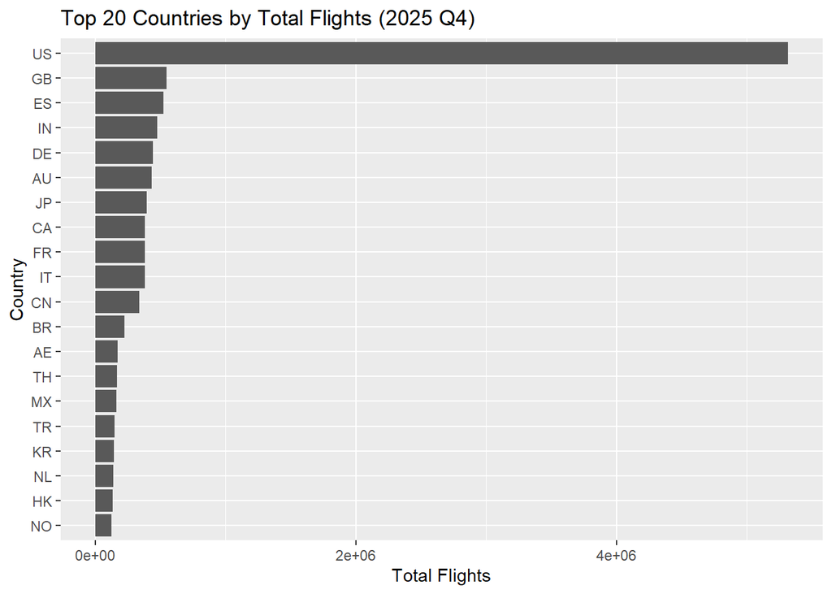

```r
ggplot(flight_by_country_df |> head(20),
       aes(x = reorder(country, total_flights),
           y = total_flights)) +
  geom_col() +
  coord_flip() +
  labs(
    x = "Country",
    y = "Total Flights",
    title = "Top 20 Countries by Total Flights (2025 Q4)"
  )
```

## 3. Create Connectivity Category

We created a categorical variable to distinguish high-connectivity countries from lower-connectivity countries.

```r
flight_by_country_df <-
  flight_by_country_df |>
  mutate(
    connectivity_level = if_else(
      row_number() <= 20,
      "High Connectivity",
      "Lower Connectivity"
    )
  )

glimpse(flight_by_country_df)
```

```
Rows: 160
Columns: 3
$ country            <chr> "US", "GB", "ES", "IN", "DE", "AU", "JP", "CA", "FR…
$ total_flights      <int> 5317570, 548553, 524337, 475126, 444115, 436777, 39…
$ connectivity_level <chr> "High Connectivity", "High Connectivity", "High Con…
```

# 5) Part V: Group Information

## Topic and Lab Section

Our project investigates structural inequality in global air connectivity during 2025 Q4. We analyze how flight volume is distributed across countries and major airport hubs to identify central and peripheral regions in the global aviation network.

Course: INFO 201 B Section: BD, group 6 TA: Anna Huang

## Team Members

Harry Cheng (Informatics, University of Washington; harrist@uw.edu) is interested in web development and data analysis.

Maggie Zhou (The Information School, University of Washington; meiqiz2@uw.edu)is interested in AI research, exploring the algorithms behind AI and the thought processes behind AI research.

Mohamed Abdi (University of Washington; mabdi8@uw.edu) is interested in structural inequality and global systems analysis. Im passionate about using data science to examine patterns of access, infrastructure, and policy.

## Coding Notes

Library of *dplyr*, *stringr* and *ggplot2* were covered in INFO 201 lectures and labs. We used *arrow* in order to load flight data from “.parquet” file (instead of the usual “.csv” in INFO 201)

ChatGPT was used during the project for text revisions and code suggestions (we always double check them and do some changes based the context of our project).